# PML Project Report

Krystle Sawyer

2023-02-28

## Overview

The goal of this project is to predict the manner in which 6 participants did their exercise (sitting, sitting down, standing, standing up, walking). This is the “classe” variable in the training set. Other variables may be utilized to predict with. This report describes how the model was built, how cross validation was used, what I think the expected out of sample error is, and why I made the choices I did. This prediction model will also be used to predict 20 different test cases.

## Data

The training data for this project is available here:

https://d396qusza40orc.cloudfront.net/predmachlearn/pml-training.csv

The test data is available here:

https://d396qusza40orc.cloudfront.net/predmachlearn/pml-testing.csv

The data for this project comes from this source: http://groupware.les.inf.puc-rio.br/har.

## Loading and cleaning data

Install packages, load and set seed

```r
library(caret)
library(randomForest)
```

```r
library(rpart)
library(rpart.plot)
library(ggplot2)
library(dplyr)
library(gbm)
set.seed(250)
```

Load data

```r
training_data <-read.csv("pml-training.csv")
test_data <-read.csv("pml-testing.csv")

dim(training_data)
```

```
## [1] 19622   160
```

```r
dim(test_data)
```

```
## [1]  20 160
```

Clean data: Remove all columns with NAs, Remove near zero variance predictos, remove ID variables.

```r
#remove columns with NA

training_data <- training_data %>% select_if(~ !any(is.na(.)))
test_data <- test_data %>% select_if(~ !any(is.na(.)))

dim(training_data)
```

```
## [1] 19622    93
```

```r
dim(test_data)
```

```
## [1] 20 60
```

```r
#remove near zero variance predictors with caret package
nzv <- nearZeroVar(training_data)

training_data<- training_data[,-nzv]
test_data<- test_data[,-nzv]

#remove ID variables
training_data<-training_data[,-(1:5)]
test_data<-test_data[,-(1:5)]
```

## Partition of the Data

```r
in_train  <- createDataPartition(training_data$classe, p=0.75, list=FALSE)
train_set <- training_data[ in_train, ]
test_set  <- training_data[-in_train, ]

dim(train_set)
```

```
## [1] 14718    54
```

## Building of the Models

Decision Tree:

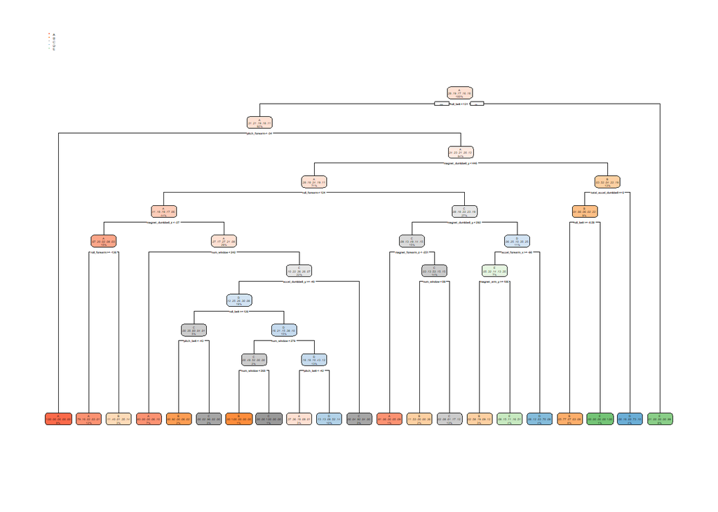

```r
decisiontree <- rpart(classe~., data = train_set, method = 'class')
rpart.plot(decisiontree)
```

Making a prediction:

```r
predict_decisiontree <-predict(decisiontree, newdata=test_set, type = 'class')

#counts number classified into classe
table_mat <- table(test_set$classe, predict_decisiontree)
table_mat
```

```
##    predict_decisiontree
##        A    B    C    D    E
##   A 1244   39   18   76   18
##   B  174  561   68  119   27
##   C   27   76  679   51   22
##   D   48   57  134  525   40
##   E   42  111   65  109  574
```

```r
conf_matrix<-confusionMatrix(predict_decisiontree, factor(test_set$classe))
conf_matrix
```

```
## Confusion Matrix and Statistics
##
##           Reference
## Prediction    A    B    C    D    E
##          A 1244  174   27   48   42
##          B   39  561   76   57  111
##          C   18   68  679  134   65
##          D   76  119   51  525  109
##          E   18   27   22   40  574
##
## Overall Statistics
##
##                Accuracy : 0.7306
##                  95% CI : (0.718, 0.743)
##     No Information Rate : 0.2845
##     P-Value [Acc > NIR] : < 2.2e-16
##
##                   Kappa : 0.6584
##
##  Mcnemar's Test P-Value : < 2.2e-16
##
## Statistics by Class:
##
##                      Class: A Class: B Class: C Class: D Class: E
## Sensitivity            0.8918   0.5911   0.7942   0.6530   0.6371
## Specificity            0.9171   0.9284   0.9296   0.9134   0.9733
## Pos Pred Value         0.8104   0.6647   0.7044   0.5966   0.8429
## Neg Pred Value         0.9552   0.9044   0.9553   0.9307   0.9226
## Prevalence             0.2845   0.1935   0.1743   0.1639   0.1837
## Detection Rate         0.2537   0.1144   0.1385   0.1071   0.1170
## Detection Prevalence   0.3130   0.1721   0.1966   0.1794   0.1389
## Balanced Accuracy      0.9044   0.7598   0.8619   0.7832   0.8052
```

Accuracy is at 73%

Random Forest:

```r
set.seed(250)
RFcontrol <- trainControl(method="cv", number=3, verboseIter=FALSE)
model <- train(classe ~ ., data=train_set, method="rf", trControl=RFcontrol)
model$finalModel
```

```
##
## Call:
##  randomForest(x = x, y = y, mtry = param$mtry)
##                Type of random forest: classification
##                      Number of trees: 500
## No. of variables tried at each split: 27
##
##         OOB estimate of  error rate: 0.24%
## Confusion matrix:
##      A    B    C    D    E  class.error
## A 4184    0    0    0    1 0.0002389486
## B    8 2836    3    1    0 0.0042134831
## C    0    5 2561    1    0 0.0023373588
## D    0    0    7 2404    1 0.0033167496
## E    0    1    0    7 2698 0.0029563932
```

```r
#Prediction
predRF <- predict(model, newdata= test_set)
RFconfusmatrix<- confusionMatrix(predRF, factor(test_set$classe))
RFconfusmatrix
```

```
## Confusion Matrix and Statistics
##
##           Reference
## Prediction    A    B    C    D    E
##          A 1394    2    0    0    0
##          B    1  947    1    0    0
##          C    0    0  853    2    0
##          D    0    0    1  802    0
##          E    0    0    0    0  901
##
## Overall Statistics
##
##                Accuracy : 0.9986
##                  95% CI : (0.9971, 0.9994)
##     No Information Rate : 0.2845
##     P-Value [Acc > NIR] : < 2.2e-16
##
##                   Kappa : 0.9982
##
##  Mcnemar's Test P-Value : NA
##
## Statistics by Class:
##
##                      Class: A Class: B Class: C Class: D Class: E
## Sensitivity            0.9993   0.9979   0.9977   0.9975   1.0000
## Specificity            0.9994   0.9995   0.9995   0.9998   1.0000
## Pos Pred Value         0.9986   0.9979   0.9977   0.9988   1.0000
## Neg Pred Value         0.9997   0.9995   0.9995   0.9995   1.0000
## Prevalence             0.2845   0.1935   0.1743   0.1639   0.1837
## Detection Rate         0.2843   0.1931   0.1739   0.1635   0.1837
## Detection Prevalence   0.2847   0.1935   0.1743   0.1637   0.1837
## Balanced Accuracy      0.9994   0.9987   0.9986   0.9986   1.0000
```

Accuracy for the Random Forest model reflects 99.8% and is the best of the two options to be utilized for the quiz.

Applying Model to Quiz:

```r
test_data <-read.csv("pml-testing.csv")

quiz_prediction <- predict(model, newdata= test_data)
quiz_prediction
```

```
##  [1] B A B A A E D B A A B C B A E E A B B B
## Levels: A B C D E
```